# Meta-analysis of avian responses and butterfly eyespots

- Show All Code
- Hide All Code
- View Source

Author

**Mizuno et al.**

Published

August 29, 2023

## 1 Setting up

```r
pacman::p_load(ape,
               DT,
               here,
               tidyverse,
               metafor,
               miWQS,
               orchaRd,
               pnder,
               parallel,
               viridis)
```

## 2 prepare datasets for analysis

::: {.panel-tabset}

### 2.1 Read datasets

```r
dat_predator <- read.csv(here("data/predator_22072023.csv"), header = T, fileEncoding = "CP932")

dat_all <-  read.csv(here("data/all_15082023.csv"), header = T, fileEncoding = "CP932")
```

### 2.2 Calculate effect size and its variance

Create function for calculating effect size and its variance

```r
# function for calculating effect size (lnRR)
effect_lnRR <- function(dt) {
  # replace 0 in "C_mean", "T_sd", "C_sd", "C_proportion" with each minimum values
  # if proportion too extreme value, replace minimum value (only "T_proportion")

  dt <- dt %>%
    mutate(C_mean = ifelse(C_mean == 0, 0.04, C_mean))
  dt <- dt %>%
    mutate(T_sd = ifelse(T_sd == 0, 0.01, T_sd))
  dt <- dt %>%
    mutate(C_sd = ifelse(C_sd == 0, 0.05, C_sd))
  dt <- dt %>%
    mutate(C_proportion = ifelse(C_proportion == 0, 0.01, C_proportion))
  dt <- dt %>%
    mutate(T_proportion = ifelse(T_proportion < 0.01, 0.01, T_proportion))
  dt <- dt %>%
    mutate(T_proportion = ifelse(T_proportion  == 1, 0.9, T_proportion))

  # copy dataset for adding effect size and its variation (lnRR /lnRR_var) column
  dt1 <- dt %>%
    mutate(
      lnRR = NA,
      lnRR_var = NA
    )

  for (i in seq_len(nrow(dt1))) {
    Tn <- dt1$Tn[i]
    Cn <- dt1$Cn[i]
    T_mean <- dt1$T_mean[i]
    C_mean <- dt1$C_mean[i]
    T_proportion <- dt1$T_proportion[i]
    C_proportion <- dt1$C_proportion[i]
    T_sd <- dt1$T_sd[i]
    C_sd <- dt1$C_sd[i]
    Response <- dt1$Response[i]
    Measure <- dt1$Measure[i]
    Study_design <- dt1$Study_design[i]
    Direction <- dt1$Direction[i]

    # continuous data - using escalc() (metafor package)
    if (Response == "continuous" & Study_design == "independent") {

      effect <- escalc(
        measure = "ROM",
        n1i = Tn, n2i = Cn,
        m1i = T_mean, m2 = C_mean,
        sd1i = T_sd, sd2i = C_sd,
        var.names = c("lnRR", "lnRR_var")
      )

      dt1$lnRR[i] <- effect$lnRR
      dt1$lnRR_var[i] <- effect$lnRR_var
    } else if (Response == "continuous" & Study_design == "dependent") {

      effect <- escalc(
        measure = "ROMC",
        ni = (Tn + Cn) / 2,
        m1i = T_mean, m2 = C_mean,
        sd1i = T_sd, sd2i = C_sd,
        ri = 0.5,
        var.names = c("lnRR", "lnRR_var")
      )

      dt1$lnRR[i] <- effect$lnRR
      dt1$lnRR_var[i] <- effect$lnRR_var
    }

    # proportion data (no sd values)
    else if (Response == "proportion1" & Study_design == "independent") {

      T_proportion <- replace(
        T_proportion, Direction == "Decrease",
        (1 - T_proportion[Direction == "Decrease"])
      )
      C_proportion <- replace(
        C_proportion, Direction == "Decrease",
        (1 - C_proportion[Direction == "Decrease"])
      )

      # transform proportion value
      asin_trans <- function(proportion) {
        trans <- asin(sqrt(proportion))
        trans
      }

      T_proportion <- asin_trans(T_proportion)
      C_proportion <- asin_trans(C_proportion)

      # calculate lnRR and lnRR variance
      lnRR_pro1 <- log(T_proportion / C_proportion)
      lnRR_var_pro1 <- (1 / sqrt(8))^2 * (1 / (T_proportion^2 * Tn) +
        1 / (C_proportion^2 * Cn))

      dt1$lnRR[i] <- lnRR_pro1
      dt1$lnRR_var[i] <- lnRR_var_pro1

    } else if (Response == "proportion1" & Study_design == "dependent") {

      T_proportion <- replace(
        T_proportion, Direction == "Decrease",
        (1 - T_proportion[Direction == "Decrease"])
      )
      C_proportion <- replace(
        C_proportion, Direction == "Decrease",
        (1 - C_proportion[Direction == "Decrease"])
      )

      # transform proportion value
      asin_trans <- function(proportion) {
        trans <- asin(sqrt(proportion))
        trans
      }

      T_proportion <- asin_trans(T_proportion)
      C_proportion <- asin_trans(C_proportion)

      # calculate lnRR and lnRR variance
      lnRR_pro1 <- log(T_proportion / C_proportion)
      lnRR_var_pro1 <- (1 / sqrt(8))^2 * (1 / (T_proportion^2 * Tn) +
        1 / (C_proportion^2 * Cn)) -
        2 * 0.5 * sqrt((1 / sqrt(8))^2 * (1 / (T_proportion^2 * Tn))) *
          sqrt((1 / sqrt(8))^2 * (1 / (C_proportion^2 * Cn)))

      dt1$lnRR[i] <- lnRR_pro1
      dt1$lnRR_var[i] <- lnRR_var_pro1
    }

    # proportion data (exist sd values)
    else if (Response == "proportion2" & Study_design == "independent") {

        T_proportion <- replace(
        T_proportion, Direction == "Decrease",
        (1 - T_proportion[Direction == "Decrease"])
      )
      C_proportion <- replace(
        C_proportion, Direction == "Decrease",
        (1 - C_proportion[Direction == "Decrease"])
      )

      # transform proportion mean value
      asin_trans <- function(proportion) {
        trans <- asin(sqrt(proportion))
        trans
      }

      T_SD <- T_sd^2 / (4 * (T_proportion) * (1 - (T_proportion)))
      C_SD <- C_sd^2 / (4 * (C_proportion) * (1 - (C_proportion)))

      T_proportion <- asin_trans(T_proportion)
      C_proportion <- asin_trans(C_proportion)

      # calculate lnRR and lnRR variance
      lnRR_pro2 <- log(T_proportion / C_proportion)
      lnRR_var_pro2 <- (T_SD)^2 * (1 / (T_proportion^2 * Tn)) +
        (C_SD)^2 * (1 / (C_proportion^2 * Cn))

      dt1$lnRR[i] <- lnRR_pro2
      dt1$lnRR_var[i] <- lnRR_var_pro2

    } else if (Response == "proportion2" & Study_design == "dependent") {

        T_proportion <- replace(
        T_proportion, Direction == "Decrease",
        (1 - T_proportion[Direction == "Decrease"])
      )
      C_proportion <- replace(
        C_proportion, Direction == "Decrease",
        (1 - C_proportion[Direction == "Decrease"])
      )

      # transform proportion mean value
      asin_trans <- function(proportion) {
        trans <- asin(sqrt(proportion))
        trans
      }

      T_SD <- T_sd^2 / (4 * (T_proportion) * (1 - (T_proportion)))
      C_SD <- C_sd^2 / (4 * (C_proportion) * (1 - (C_proportion)))

      T_proportion <- asin_trans(T_proportion)
      C_proportion <- asin_trans(C_proportion)

      # calculate lnRR and lnRR variance
      lnRR_pro2 <- log(T_proportion / C_proportion)
      lnRR_var_pro2 <- (T_SD)^2 * (1 / (T_proportion^2 * Tn)) +
        (C_SD)^2 * (1 / (C_proportion^2 * Cn)) -
        2 * 0.5 * sqrt((T_SD)^2 * (1 / (T_proportion^2 * Tn))) *
          sqrt((C_SD)^2 * (1 / (C_proportion^2 * Cn)))

      dt1$lnRR[i] <- lnRR_pro2
      dt1$lnRR_var[i] <- lnRR_var_pro2
    }
  }

  return(dt1)
}
```

Calculate lnRR and lnRR variance

```r
dat_pred <- effect_lnRR(dat_predator)
dat <- effect_lnRR(dat_all)

# add obseravation id
dat_pred$Obs_ID <- 1:nrow(dat_pred)
dat$Obs_ID <- 1:nrow(dat)

# use vcalc to calculate variance-covariance matrix
VCV_pred <- vcalc(vi = lnRR_var,
                  cluster = Cohort_ID,
                  subgroup = Obs_ID,
                  data = dat_pred)

VCV <- vcalc(vi = lnRR_var,
             cluster = Cohort_ID,
             obs = Obs_ID,
             rho = 0.5,
             data = dat)
```

### 2.3 Final dataset for meta-analysis

```r
datatable(dat, caption = "Dataset for meta-analysis",
          options = list(pageLength = 10, scrollX = TRUE))
```

|  | Study_ID | Cohort_ID | Shared_control_ID | Year | Country | Data_source | Data_location | Bird_species | Bird_common_name | Prey_species | Prey_common_name | Response | Measure | Direction | Detail_result | Note_result | Treatment_stimulus | Number_pattern | Diameter_pattern | Area_pattern | Area_background | Area_ratio | Shape_pattern | Control_stimulus | Note_stimulus | Type_prey | Shape_prey | Diet_bird | Bird_sex | … |
| --- | --- | --- | --- | --- | --- | --- | --- | --- | --- | --- | --- | --- | --- | --- | --- | --- | --- | --- | --- | --- | --- | --- | --- | --- | --- | --- | --- | --- | --- | --- |
| 1 | Blest_1957 | Blest_1957_1 | Blest_1957_a | 1957 | UK | table. 6 | p.230 | Emberiza_sulphurata | yellow bunting | Inachis_io | peacock butterfly | continuous | latency | Increase | number of escape response | total number of day 1 to day 5, if the bird fears T more than C, the number of times increases, so AM reversed the value (treated as latency category) | eyespot | 4 | 9.91 | 77.13246137 | 1370.3596 | 0.22514517 | eyespot | no pattern |  | real | butterfly | grainivore |  | … |
| 2 | Jones_1980 | Jones_1980_1 | Jones_1980_a | 1980 | UK | table. 1 | p.214 | Gallus_gallus | domestic fowl | none | none | continuous | latency | Increase | latency to first step |  | eyespot | 1 | 25 | 490.8738521 | 3200 | 0.153398079 | eyespot | no pattern |  | artificial | abstract_stimuli | omnivore | male | … |
| 3 | Jones_1980 | Jones_1980_1 | Jones_1980_a | 1980 | UK | table. 1 | p.214 | Gallus_gallus | domestic fowl | none | none | continuous | latency | Increase | latency to first step |  | eyespot | 2 | 25 | 490.8738521 | 3200 | 0.306796158 | eyespot | no pattern |  | artificial | abstract_stimuli | omnivore | male | … |
| 4 | Jones_1980 | Jones_1980_1 | Jones_1980_a | 1980 | UK | table. 1 | p.214 | Gallus_gallus | domestic fowl | none | none | continuous | latency | Increase | duration of freezing |  | eyespot | 1 | 25 | 490.8738521 | 3200 | 0.153398079 | eyespot | no pattern |  | artificial | abstract_stimuli | omnivore | male | … |
| 5 | Jones_1980 | Jones_1980_1 | Jones_1980_a | 1980 | UK | table. 1 | p.214 | Gallus_gallus | domestic fowl | none | none | continuous | latency | Increase | duration of freezing |  | eyespot | 2 | 25 | 490.8738521 | 3200 | 0.306796158 | eyespot | no pattern |  | artificial | abstract_stimuli | omnivore | male | … |
| 6 | Jones_1980 | Jones_1980_1 | Jones_1980_a | 1980 | UK | table. 1 | p.214 | Gallus_gallus | domestic fowl | none | none | continuous | latency | Increase | duration of sitting |  | eyespot | 1 | 25 | 490.8738521 | 3200 | 0.153398079 | eyespot | no pattern |  | artificial | abstract_stimuli | omnivore | male | … |
| 7 | Jones_1980 | Jones_1980_1 | Jones_1980_a | 1980 | UK | table. 1 | p.214 | Gallus_gallus | domestic fowl | none | none | continuous | latency | Increase | duration of sitting |  | eyespot | 2 | 25 | 490.8738521 | 3200 | 0.306796158 | eyespot | no pattern |  | artificial | abstract_stimuli | omnivore | male | … |
| 8 | Jones_1980 | Jones_1980_1 | Jones_1980_a | 1980 | UK | table. 1 | p.214 | Gallus_gallus | domestic fowl | none | none | continuous | latency | Increase | duration of lying |  | eyespot | 1 | 25 | 490.8738521 | 3200 | 0.153398079 | eyespot | no pattern |  | artificial | abstract_stimuli | omnivore | male | … |
| 9 | Jones_1980 | Jones_1980_1 | Jones_1980_a | 1980 | UK | table. 1 | p.214 | Gallus_gallus | domestic fowl | none | none | continuous | latency | Increase | duration of lying |  | eyespot | 2 | 25 | 490.8738521 | 3200 | 0.306796158 | eyespot | no pattern |  | artificial | abstract_stimuli | omnivore | male | … |
| 10 | Jones_1980 | Jones_1980_1 | Jones_1980_a | 1980 | UK | table. 1 | p.214 | Gallus_gallus | domestic fowl | none | none | continuous | latency | Increase | time of eye closure |  | eyespot | 1 | 25 | 490.8738521 | 3200 | 0.153398079 | eyespot | no pattern |  | artificial | abstract_stimuli | omnivore | male | … |

[output cut: 253 more lines]

### 2.4 Check phylogenetic relatedness

If phylogeny do not explain heterogeniety much, we will not need to consider it and the two datasets can be merged.

We used meta-analytical models to calculate total I2 (a measure of heterogeneity not caused by sampling error; Higgins. et al., 2003) and the partial I2 explained by each random factor.

Based on this, we need not to consider phylogenetic relatedness from our meta-regressions as this random factor did not explain much of the heterogeneity between effect sizes (partial I2 < 0.001%), then we can combine two datasets (predator and prey) for meta-analysis.

```r
trees <- read.nexus(here("data/bird_phy.nex"))
phy_model <- function(cor_tree = vcv_tree){
            model <- rma.mv(yi = lnRR,
                            V = VCV_pred,
                            random = list(~1 | Study_ID,
                                          ~1 | Shared_control_ID,
                                          ~1 | Cohort_ID,
                                          ~1 | Obs_ID,
                                          ~1 | Bird_species,
                                          ~1 | Phylogeny),
                            R = list(Phylogeny = cor_tree),
                            test = "t",
                            method = "REML",
                            sparse = TRUE,
                            data = dat_pred)
  model
}

tree_50 <- trees[1:50]
vcv_tree_50 <- map(tree_50, ~vcv(.x, corr = TRUE))


# Run multiple meta-analyses with 50 different trees and obtain the combined result


ma_50 <- mclapply(vcv_tree_50, phy_model, mc.cores = 8)
```

```r
ma_50 <- readRDS(here("Rdata", "ma_50.RDS"))

# combining the results
est_50 <- map_dbl(ma_50, ~ .x$b[[1]])
se_50 <-  map_dbl(ma_50, ~ .x$se)
df_50 <- c(rbind(est_50, se_50))

# creating an array required by pool.mi
my_array <- array(df_50, dim = c(1, 2, 50))

com_res <- round(pool.mi(my_array), 4)
```

```r
knitr::kable(com_res, caption = "Combined result of 50 phylogenetic trees")
```

Combined result of 50 phylogenetic trees

| pooled.mean | pooled.total.se | se.within | se.between | relative.inc.var | frac.miss.info | CI.1 | CI.2 | p.value |
| --- | --- | --- | --- | --- | --- | --- | --- | --- |
| 0.1394 | 0.1192 | 0.1192 | 0 | 0 | 0 | -0.0943 | 0.3731 | 0.2424 |

```r
sigma2_mod <- do.call(rbind, lapply(ma_50, function(x) x$sigma2))
sigma2_mod <- data.frame(sigma2_mod)

colnames(sigma2_mod) <- c("sigma^2.1_Study_ID", "sigma^2.2_SharedControl_ID",
                          "sigma^2.3_Cohort_ID", "sigma^2.4_Obs_ID",
                          "sigma^2.5_BirdSpecies", "sigma^2.6_Phylogeny")

sigma2_mod <- round(colMeans(sigma2_mod), 4)

knitr::kable(sigma2_mod, caption = "Average variance components")
```

Average variance components

|  | x |
| --- | --- |
| sigma^2.1_Study_ID | 0.0000 |
| sigma^2.2_SharedControl_ID | 0.0923 |
| sigma^2.3_Cohort_ID | 0.1009 |
| sigma^2.4_Obs_ID | 0.5323 |
| sigma^2.5_BirdSpecies | 0.0000 |
| sigma^2.6_Phylogeny | 0.0000 |

**We got 1000 phylogenetic trees from [BirdTree.org](https://birdtree.org)**

Only 50 trees are used as in [Nakagawa & Villemereuil (2019)](https://doi.org/10.1093/sysbio/syy089)

## 3 Meta-analysis

We used meta-analytical models to calculate total I2 (a measure of heterogeneity not caused by sampling error; Higgins. et al., 2003) and the partial I2 explained by each random factor.

**Which random effects remove in our models?**

We can remove *Shared control ID* and *Cohort ID*

```r
# I exclude cohort_ID because sigma^2.2 = 0 and I2 = 0
ma_all <- rma.mv(yi = lnRR,
                  V = VCV,
                  random = list(~1 | Study_ID,
                                ~1 | Shared_control_ID,
                                ~1 | Cohort_ID,
                                ~1 | Obs_ID),
                  test = "t",
                  method = "REML",
                  sparse = TRUE,
                  data = dat)

summary(ma_all)
```

```
Multivariate Meta-Analysis Model (k = 263; method: REML)

   logLik   Deviance        AIC        BIC       AICc
-248.2436   496.4871   506.4871   524.3289   506.7215

Variance Components:

            estim    sqrt  nlvls  fixed             factor
sigma^2.1  0.0490  0.2214     32     no           Study_ID
sigma^2.2  0.0000  0.0000     88     no  Shared_control_ID
sigma^2.3  0.0000  0.0000    157     no          Cohort_ID
sigma^2.4  0.2423  0.4923    263     no             Obs_ID

Test for Heterogeneity:
Q(df = 262) = 6322.6734, p-val < .0001

Model Results:

estimate      se    tval   df    pval   ci.lb   ci.ub
  0.2086  0.0597  3.4913  262  0.0006  0.0909  0.3262  ***

---
Signif. codes:  0 '***' 0.001 '**' 0.01 '*' 0.05 '.' 0.1 ' ' 1
```

```r
i2 <- round(i2_ml(ma_all), 4)
```

| I2_Total | I2_Study_ID | I2_Shared_control_ID | I2_Cohort_ID | I2_Obs_ID |
| --- | --- | --- | --- | --- |
| 99.8442 | 16.7983 | 0 | 0 | 83.0458 |

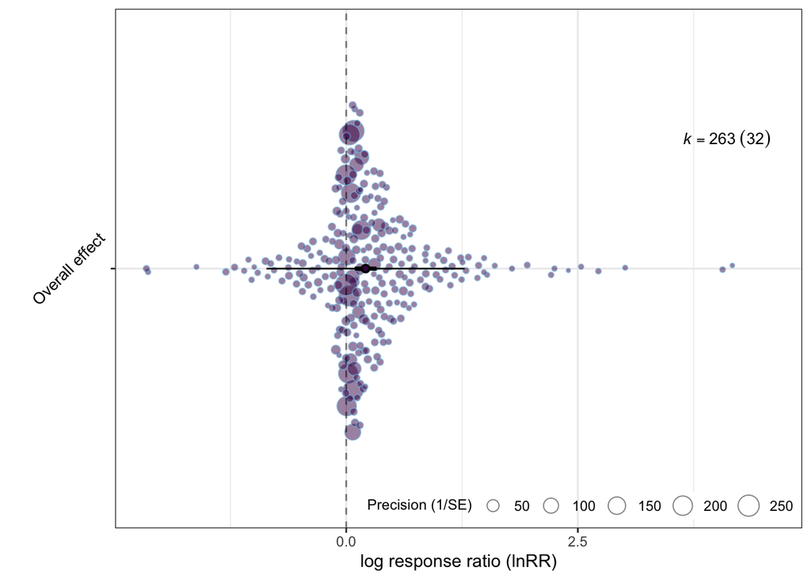

```r
orchard_plot(ma_all,
              group = "Study_ID",
              xlab = "log response ratio (lnRR)",
              angle = 45) +
              scale_x_discrete(labels = c("Overall effect")) +
              scale_fill_viridis_d()
```

## 4 Meta-regressions: uni-moderator

**Pattern type**

Eyespot vs. conspicuous patterns - Is there significant difference of effect size between two patterns?

```r
#normal model
mr_eyespot <- rma.mv(yi = lnRR,
                    V = VCV,
                    mods = ~ Treatment_stimulus,
                    random = list(~1 | Study_ID,
                                  ~1 | Obs_ID),
                    test = "t",
                    method = "REML",
                    sparse = TRUE,
                    data = dat)

summary(mr_eyespot)
```

```
Multivariate Meta-Analysis Model (k = 263; method: REML)

   logLik   Deviance        AIC        BIC       AICc
-247.4652   494.9305   502.9305   517.1886   503.0867

Variance Components:

            estim    sqrt  nlvls  fixed    factor
sigma^2.1  0.0534  0.2312     32     no  Study_ID
sigma^2.2  0.2426  0.4926    263     no    Obs_ID

Test for Residual Heterogeneity:
QE(df = 261) = 6290.4224, p-val < .0001

Test of Moderators (coefficient 2):
F(df1 = 1, df2 = 261) = 0.1628, p-val = 0.6869

Model Results:

                           estimate      se    tval   df    pval    ci.lb
intrcpt                      0.1783  0.0980  1.8199  261  0.0699  -0.0146
Treatment_stimuluseyespot    0.0442  0.1096  0.4035  261  0.6869  -0.1716
                            ci.ub
intrcpt                    0.3712  .
Treatment_stimuluseyespot  0.2601

---
Signif. codes:  0 '***' 0.001 '**' 0.01 '*' 0.05 '.' 0.1 ' ' 1
```

```r
i2_1 <- round(i2_ml(mr_eyespot), 4)
```

| I2_Total | I2_Study_ID | I2_Obs_ID |
| --- | --- | --- |
| 99.8466 | 18.0186 | 81.828 |

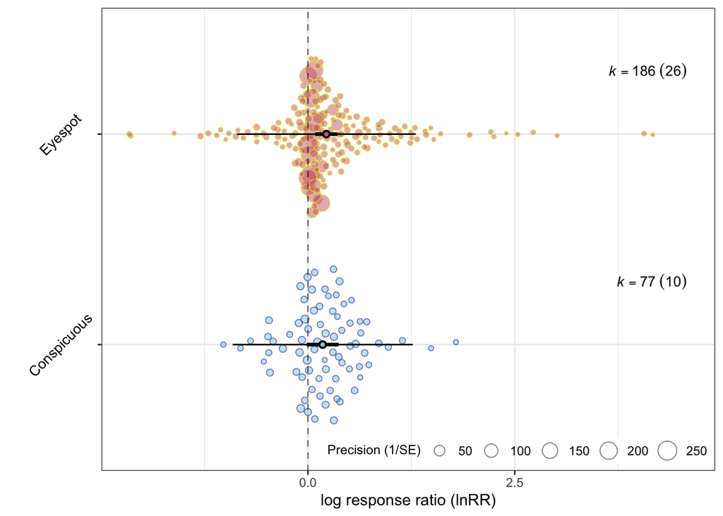

```r
orchard_plot(mr_eyespot,
            mod = "Treatment_stimulus",
            group = "Study_ID",
            xlab = "log response ratio (lnRR)",
            angle = 45) +
            scale_colour_viridis_d(option = "plasma")
```

```r
# intercept-removed model
mr_eyespot1 <- rma.mv(yi = lnRR,
                      V = VCV,
                      mods = ~ Treatment_stimulus -1,
                      random = list(~1 | Study_ID,
                                    ~1 | Obs_ID),
                      test = "t",
                      method = "REML",
                      sparse = TRUE,
                      data = dat)

summary(mr_eyespot1)
```

```
Multivariate Meta-Analysis Model (k = 263; method: REML)

   logLik   Deviance        AIC        BIC       AICc
-247.4652   494.9305   502.9305   517.1886   503.0867

Variance Components:

            estim    sqrt  nlvls  fixed    factor
sigma^2.1  0.0534  0.2312     32     no  Study_ID
sigma^2.2  0.2426  0.4926    263     no    Obs_ID

Test for Residual Heterogeneity:
QE(df = 261) = 6290.4224, p-val < .0001

Test of Moderators (coefficients 1:2):
F(df1 = 2, df2 = 261) = 5.9203, p-val = 0.0031

Model Results:

                               estimate      se    tval   df    pval    ci.lb
Treatment_stimulusconspicuous    0.1783  0.0980  1.8199  261  0.0699  -0.0146
Treatment_stimuluseyespot        0.2225  0.0696  3.1974  261  0.0016   0.0855
                                ci.ub
Treatment_stimulusconspicuous  0.3712   .
Treatment_stimuluseyespot      0.3596  **

---
Signif. codes:  0 '***' 0.001 '**' 0.01 '*' 0.05 '.' 0.1 ' ' 1
```

**Pattern diameter (mm)**

```r
dat$Log_diameter <- log(dat$Diameter_pattern)

mr_diameter <- rma.mv(yi = lnRR,
                      V = VCV,
                      mods = ~ Log_diameter,
                      random = list(~1 | Study_ID,
                                    ~1 | Obs_ID),
                      test = "t",
                      method = "REML",
                      sparse = TRUE,
                      data = dat)

summary(mr_diameter)
```

```
Multivariate Meta-Analysis Model (k = 263; method: REML)

   logLik   Deviance        AIC        BIC       AICc
-244.4086   488.8173   496.8173   511.0753   496.9735

Variance Components:

            estim    sqrt  nlvls  fixed    factor
sigma^2.1  0.0440  0.2099     32     no  Study_ID
sigma^2.2  0.2372  0.4870    263     no    Obs_ID

Test for Residual Heterogeneity:
QE(df = 261) = 6288.3226, p-val < .0001

Test of Moderators (coefficient 2):
F(df1 = 1, df2 = 261) = 6.0358, p-val = 0.0147

Model Results:

              estimate      se     tval   df    pval    ci.lb   ci.ub
intrcpt        -0.1679  0.1634  -1.0274  261  0.3052  -0.4897  0.1539
Log_diameter    0.1945  0.0792   2.4568  261  0.0147   0.0386  0.3504  *

---
Signif. codes:  0 '***' 0.001 '**' 0.01 '*' 0.05 '.' 0.1 ' ' 1
```

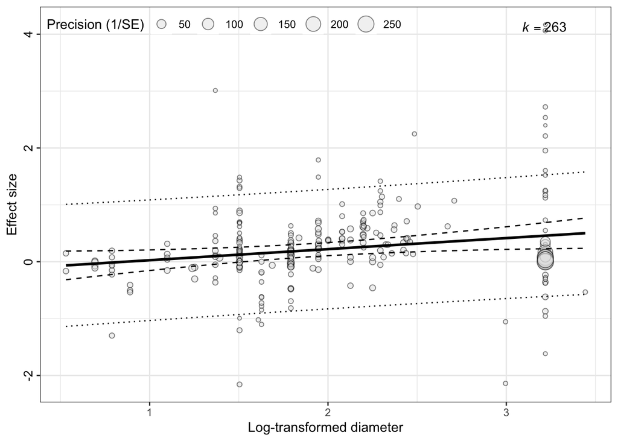

```r
bubble_plot(mr_diameter,
            mod = "Log_diameter",
            group = "Study_ID",
            xlab = "Log-transformed diameter")
```

**Pattern area (mm²)**

```r
dat$Log_area <- log(dat$Area_pattern)

mr_area <- rma.mv(yi = lnRR,
                  V = VCV,
                  mods = ~ Log_area,
                  random = list(~1 | Study_ID,
                                ~1 | Obs_ID),
                  test = "t",
                  method = "REML",
                  sparse = TRUE,
                  data = dat)

summary(mr_area)
```

```
Multivariate Meta-Analysis Model (k = 263; method: REML)

   logLik   Deviance        AIC        BIC       AICc
-243.8857   487.7714   495.7714   510.0295   495.9277

Variance Components:

            estim    sqrt  nlvls  fixed    factor
sigma^2.1  0.0483  0.2199     32     no  Study_ID
sigma^2.2  0.2351  0.4849    263     no    Obs_ID

Test for Residual Heterogeneity:
QE(df = 261) = 6283.7400, p-val < .0001

Test of Moderators (coefficient 2):
F(df1 = 1, df2 = 261) = 6.9863, p-val = 0.0087

Model Results:

          estimate      se     tval   df    pval    ci.lb   ci.ub
intrcpt    -0.1849  0.1601  -1.1554  261  0.2490  -0.5001  0.1302
Log_area    0.1106  0.0419   2.6432  261  0.0087   0.0282  0.1931  **

---
Signif. codes:  0 '***' 0.001 '**' 0.01 '*' 0.05 '.' 0.1 ' ' 1
```

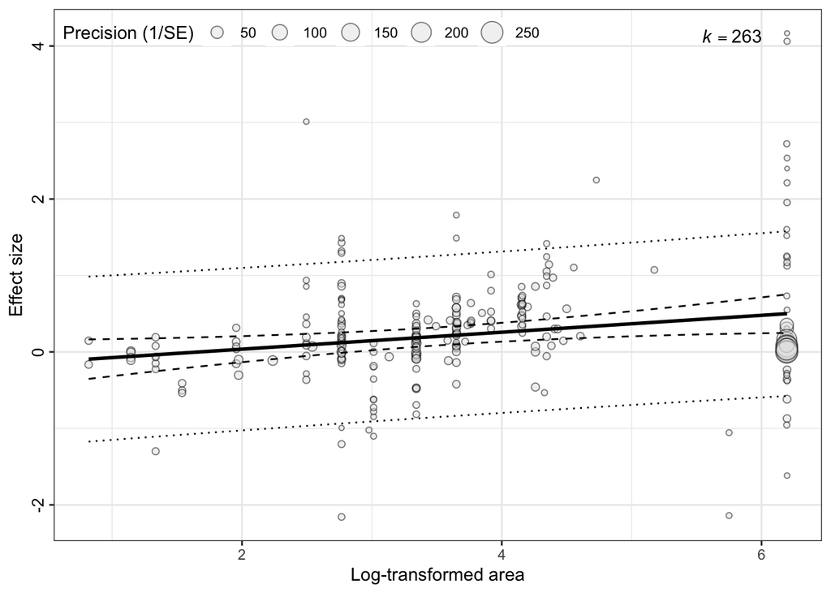

```r
bubble_plot(mr_area,
            mod = "Log_area",
            group = "Study_ID",
            xlab = "Log-transformed area")
```

**Pattern number**

```r
mr_num <- rma.mv(yi = lnRR,
                  V = VCV,
                  mods = ~ Number_pattern,
                  random = list(~1 | Study_ID,
                                ~1 | Shared_control_ID,
                                ~1 | Obs_ID),
                      test = "t",
                      method = "REML",
                      sparse = TRUE,
                      data = dat)

summary(mr_num)
```

```
Multivariate Meta-Analysis Model (k = 263; method: REML)

   logLik   Deviance        AIC        BIC       AICc
-245.6558   491.3117   501.3117   519.1343   501.5470

Variance Components:

            estim    sqrt  nlvls  fixed             factor
sigma^2.1  0.0468  0.2164     32     no           Study_ID
sigma^2.2  0.0000  0.0000     88     no  Shared_control_ID
sigma^2.3  0.2386  0.4885    263     no             Obs_ID

Test for Residual Heterogeneity:
QE(df = 261) = 6307.0850, p-val < .0001

Test of Moderators (coefficient 2):
F(df1 = 1, df2 = 261) = 4.4504, p-val = 0.0358

Model Results:

                estimate      se     tval   df    pval    ci.lb    ci.ub
intrcpt           0.3453  0.0877   3.9376  261  0.0001   0.1726   0.5180  ***
Number_pattern   -0.0579  0.0274  -2.1096  261  0.0358  -0.1119  -0.0039    *

---
Signif. codes:  0 '***' 0.001 '**' 0.01 '*' 0.05 '.' 0.1 ' ' 1
```

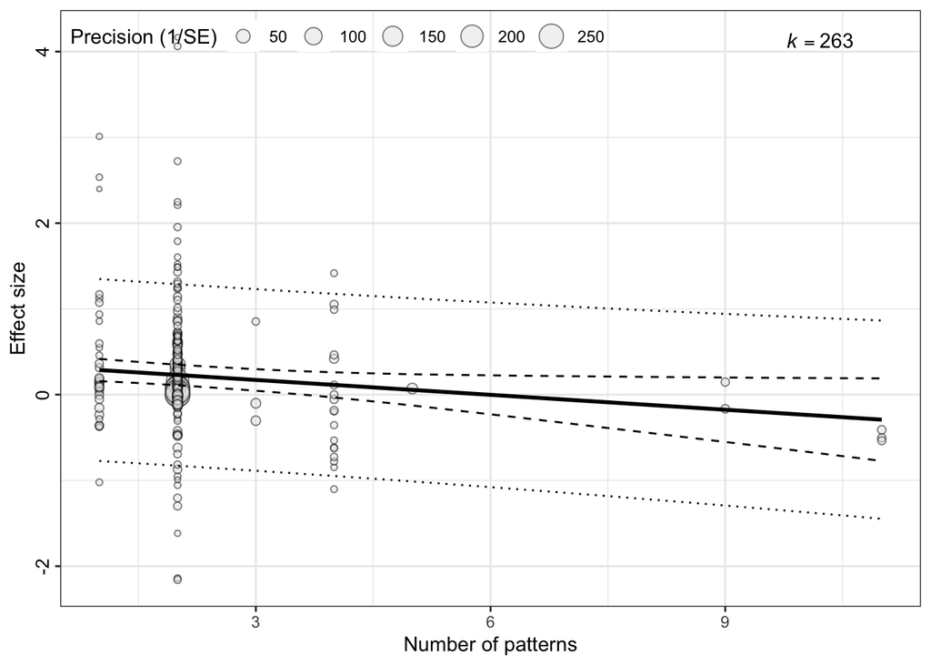

```r
bubble_plot(mr_num,
            mod = "Number_pattern",
            group = "Study_ID",
            xlab = "Number of patterns")
```

**Stimuli type**

Our dataset includes two types of stimuli: live and artificial. Is there significant difference of effect size between two stimuli?

```r
# normal model
mr_prey_type <- rma.mv(yi = lnRR,
                  V = VCV,
                  mods = ~ Type_prey,
                  random = list(~1 | Study_ID,
                                ~1 | Obs_ID),
                  test = "t",
                  method = "REML",
                  sparse = TRUE,
                  data = dat)

summary(mr_prey_type)
```

```
Multivariate Meta-Analysis Model (k = 263; method: REML)

   logLik   Deviance        AIC        BIC       AICc
-247.2961   494.5922   502.5922   516.8502   502.7484

Variance Components:

            estim    sqrt  nlvls  fixed    factor
sigma^2.1  0.0566  0.2380     32     no  Study_ID
sigma^2.2  0.2415  0.4914    263     no    Obs_ID

Test for Residual Heterogeneity:
QE(df = 261) = 6259.1358, p-val < .0001

Test of Moderators (coefficient 2):
F(df1 = 1, df2 = 261) = 0.3325, p-val = 0.5647

Model Results:

               estimate      se    tval   df    pval    ci.lb   ci.ub
intrcpt          0.1845  0.0759  2.4304  261  0.0158   0.0350  0.3339  *
Type_preyreal    0.0763  0.1324  0.5767  261  0.5647  -0.1843  0.3370

---
Signif. codes:  0 '***' 0.001 '**' 0.01 '*' 0.05 '.' 0.1 ' ' 1
```

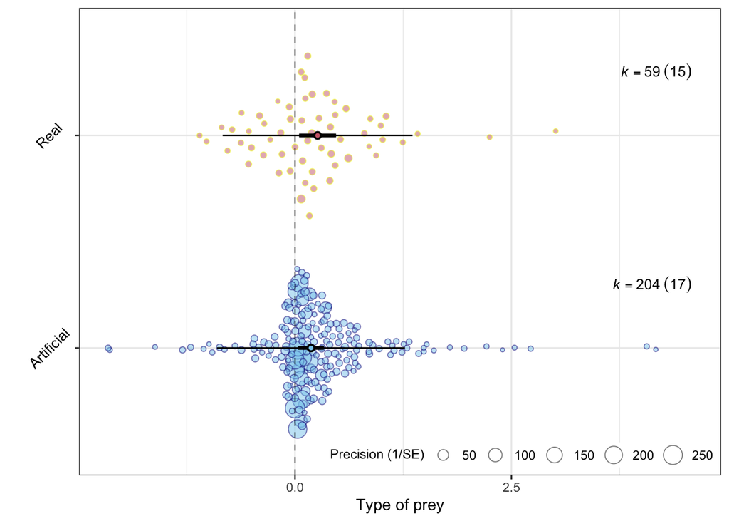

```r
orchard_plot(mr_prey_type,
              mod = "Type_prey",
              group = "Study_ID",
              xlab = "Type of prey",
              angle = 45) +
              scale_colour_viridis_d(option = "plasma")
```

```r
# intercept-removed model
mr_prey_type1 <- rma.mv(yi = lnRR,
                        V = VCV,
                        mods = ~ Type_prey,
                        random = list(~1 | Study_ID,
                                      ~1 | Obs_ID),
                        test = "t",
                        method = "REML",
                        sparse = TRUE,
                        data = dat)

summary(mr_prey_type1)
```

```
Multivariate Meta-Analysis Model (k = 263; method: REML)

   logLik   Deviance        AIC        BIC       AICc
-247.2961   494.5922   502.5922   516.8502   502.7484

Variance Components:

            estim    sqrt  nlvls  fixed    factor
sigma^2.1  0.0566  0.2380     32     no  Study_ID
sigma^2.2  0.2415  0.4914    263     no    Obs_ID

Test for Residual Heterogeneity:
QE(df = 261) = 6259.1358, p-val < .0001

Test of Moderators (coefficient 2):
F(df1 = 1, df2 = 261) = 0.3325, p-val = 0.5647

Model Results:

               estimate      se    tval   df    pval    ci.lb   ci.ub
intrcpt          0.1845  0.0759  2.4304  261  0.0158   0.0350  0.3339  *
Type_preyreal    0.0763  0.1324  0.5767  261  0.5647  -0.1843  0.3370

---
Signif. codes:  0 '***' 0.001 '**' 0.01 '*' 0.05 '.' 0.1 ' ' 1
```

**Prey shape type**

```r
mr_prey_shape <- rma.mv(yi = lnRR,
                        V = VCV,
                        mods = ~ Shape_prey - 1,
                        random = list(~1 | Study_ID,
                                      ~1 | Shared_control_ID,
                                      ~1 | Obs_ID),
                                      test = "t",
                                      method = "REML",
                                      sparse = TRUE,
                                      data = dat)

summary(mr_prey_shape)
```

```
Multivariate Meta-Analysis Model (k = 263; method: REML)

   logLik   Deviance        AIC        BIC       AICc
-243.5524   487.1049   501.1049   526.0027   501.5511

Variance Components:

            estim    sqrt  nlvls  fixed             factor
sigma^2.1  0.0560  0.2366     32     no           Study_ID
sigma^2.2  0.0000  0.0000     88     no  Shared_control_ID
sigma^2.3  0.2392  0.4890    263     no             Obs_ID

Test for Residual Heterogeneity:
QE(df = 259) = 6062.6887, p-val < .0001

Test of Moderators (coefficients 1:4):
F(df1 = 4, df2 = 259) = 3.7576, p-val = 0.0054

Model Results:

                              estimate      se    tval   df    pval    ci.lb
Shape_preyabstract_butterfly    0.3222  0.1078  2.9889  259  0.0031   0.1099
Shape_preyabstract_stimuli      0.0208  0.1868  0.1112  259  0.9115  -0.3470
Shape_preybutterfly             0.2604  0.1080  2.4120  259  0.0166   0.0478
Shape_preycaterpillar           0.0663  0.1283  0.5164  259  0.6060  -0.1864
                               ci.ub
Shape_preyabstract_butterfly  0.5345  **
Shape_preyabstract_stimuli    0.3886
Shape_preybutterfly           0.4731   *
Shape_preycaterpillar         0.3190

---
Signif. codes:  0 '***' 0.001 '**' 0.01 '*' 0.05 '.' 0.1 ' ' 1
```

## 5 Meta-regressions: multi-moderator

### 5.1 All potential moderators (full model)

```r
dat$Log_background<- log(dat$Area_background)

mr_all <- rma.mv(yi = lnRR,
                V = VCV,
                mods = ~ Treatment_stimulus +
                Log_diameter + Log_background +
                Log_area + Number_pattern +
                Type_prey + Shape_prey,
                random = list(~1 | Study_ID,
                              ~1 | Shared_control_ID,
                              ~1 | Obs_ID),
                test = "t",
                method = "REML",
                sparse = TRUE,
                data = dat)

summary(mr_all)
```

```
Multivariate Meta-Analysis Model (k = 263; method: REML)

   logLik   Deviance        AIC        BIC       AICc
-229.8962   459.7924   483.7924   526.2404   485.0870

Variance Components:

            estim    sqrt  nlvls  fixed             factor
sigma^2.1  0.0157  0.1254     32     no           Study_ID
sigma^2.2  0.0000  0.0000     88     no  Shared_control_ID
sigma^2.3  0.2283  0.4778    263     no             Obs_ID

Test for Residual Heterogeneity:
QE(df = 254) = 5679.7577, p-val < .0001

Test of Moderators (coefficients 2:9):
F(df1 = 8, df2 = 254) = 3.9645, p-val = 0.0002

Model Results:

                            estimate      se     tval   df    pval    ci.lb
intrcpt                      -0.1002  0.5052  -0.1983  254  0.8429  -1.0950
Treatment_stimuluseyespot     0.1602  0.1175   1.3631  254  0.1741  -0.0713
Log_diameter                 -0.0840  0.3392  -0.2478  254  0.8045  -0.7520
Log_background               -0.0683  0.0823  -0.8301  254  0.4073  -0.2304
Log_area                      0.2917  0.1841   1.5850  254  0.1142  -0.0707
Number_pattern               -0.0218  0.0297  -0.7322  254  0.4647  -0.0803
Type_preyreal                -0.0949  0.1377  -0.6890  254  0.4915  -0.3661
Shape_preyabstract_stimuli   -0.8388  0.2629  -3.1909  254  0.0016  -1.3565
Shape_preycaterpillar        -0.1400  0.1372  -1.0206  254  0.3084  -0.4102
                              ci.ub
intrcpt                      0.8947
Treatment_stimuluseyespot    0.3917
Log_diameter                 0.5840
Log_background               0.0938
Log_area                     0.6542
Number_pattern               0.0368
Type_preyreal                0.1764
Shape_preyabstract_stimuli  -0.3211  **
Shape_preycaterpillar        0.1302

---
Signif. codes:  0 '***' 0.001 '**' 0.01 '*' 0.05 '.' 0.1 ' ' 1
```

## 6 Publication bias

**Funnel plot**

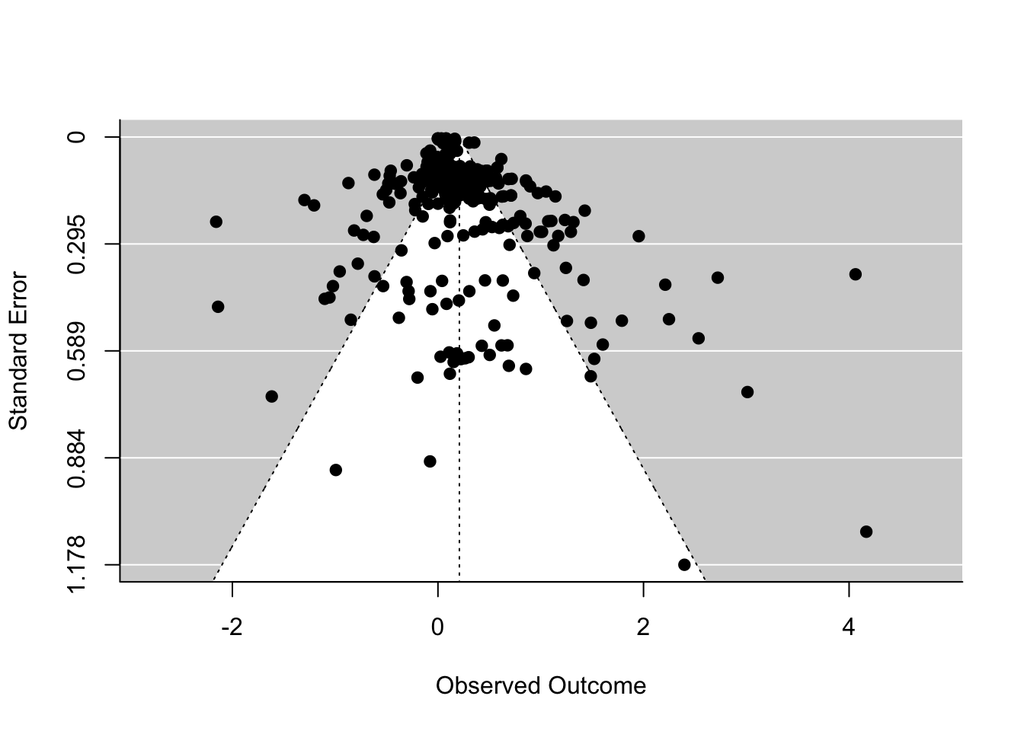

```r
funnel(ma_all)
```

**Egger’s test**

```r
df_bias <- dat %>% mutate(sqrt_inv_e_n = sqrt((Cn + Tn)/(Cn * Tn)))

bias_model <- rma.mv(yi = lnRR,
                      V = lnRR_var,
                      mods = ~sqrt_inv_e_n,
                      random = list(~1 | Study_ID,
                                    ~1 | Obs_ID),
                      test = "t",
                      method = "REML",
                      sparse = TRUE,
                      data = df_bias)

summary(bias_model)
```

```
Multivariate Meta-Analysis Model (k = 263; method: REML)

   logLik   Deviance        AIC        BIC       AICc
-245.8643   491.7285   499.7285   513.9866   499.8848

Variance Components:

            estim    sqrt  nlvls  fixed    factor
sigma^2.1  0.0959  0.3096     32     no  Study_ID
sigma^2.2  0.2159  0.4647    263     no    Obs_ID

Test for Residual Heterogeneity:
QE(df = 261) = 4119.2520, p-val < .0001

Test of Moderators (coefficient 2):
F(df1 = 1, df2 = 261) = 0.0088, p-val = 0.9254

Model Results:

              estimate      se     tval   df    pval    ci.lb   ci.ub
intrcpt         0.2428  0.1380   1.7601  261  0.0796  -0.0288  0.5145  .
sqrt_inv_e_n   -0.0363  0.3879  -0.0937  261  0.9254  -0.8001  0.7274

---
Signif. codes:  0 '***' 0.001 '**' 0.01 '*' 0.05 '.' 0.1 ' ' 1
```

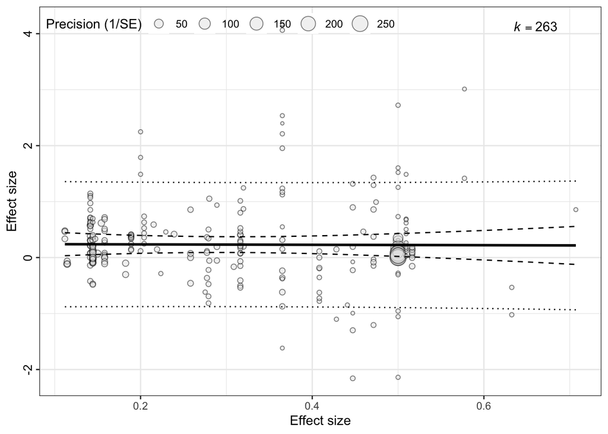

```r
bubble_plot(bias_model,
            mod = "sqrt_inv_e_n",
            group = "Study_ID",
            xlab = "Effect size")
```

**Decline effect**

```r
year_model <- rma.mv(yi = lnRR,
                      V = VCV,
                      mods = ~ Year,
                      random = list(~1 | Study_ID,
                                    ~1 | Obs_ID),
                      test = "t",
                      method = "REML",
                      sparse = TRUE,
                      data = df_bias)

summary(year_model)
```

```
Multivariate Meta-Analysis Model (k = 263; method: REML)

   logLik   Deviance        AIC        BIC       AICc
-247.3645   494.7289   502.7289   516.9870   502.8852

Variance Components:

            estim    sqrt  nlvls  fixed    factor
sigma^2.1  0.0520  0.2281     32     no  Study_ID
sigma^2.2  0.2428  0.4927    263     no    Obs_ID

Test for Residual Heterogeneity:
QE(df = 261) = 6249.4316, p-val < .0001

Test of Moderators (coefficient 2):
F(df1 = 1, df2 = 261) = 0.0057, p-val = 0.9399

Model Results:

         estimate       se     tval   df    pval     ci.lb    ci.ub
intrcpt    1.1904  12.9935   0.0916  261  0.9271  -24.3950  26.7758
Year      -0.0005   0.0065  -0.0755  261  0.9399   -0.0132   0.0122

---
Signif. codes:  0 '***' 0.001 '**' 0.01 '*' 0.05 '.' 0.1 ' ' 1
```

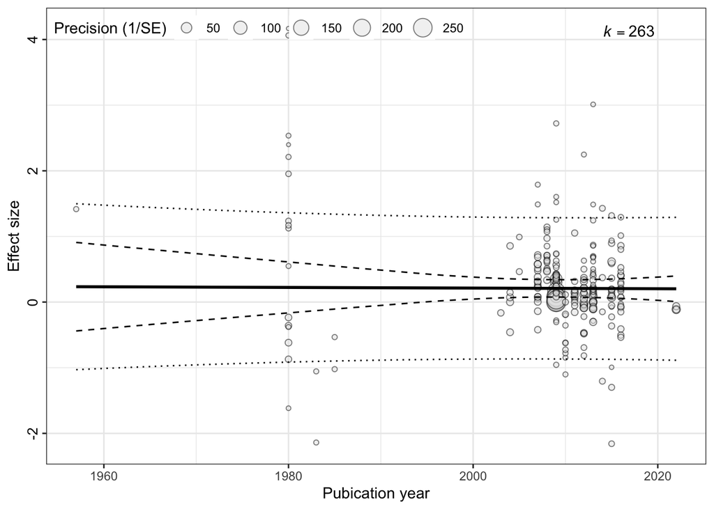

```r
bubble_plot(year_model,
            mod = "Year",
            group = "Study_ID",
            xlab = "Pubication year")
```

## 7 Additional analyses

## 8 Meta-regressions

**Dataset**

We compared effect size between two datasets (predator and prey) to see whether there is any difference in effect size between two datasets.

```r
mr_dataset <- rma.mv(yi = lnRR,
                      V = VCV,
                      mods = ~ Dataset,
                      random = list(~1 | Study_ID,
                                    ~1 | Obs_ID),
                      test = "t",
                      method = "REML",
                      sparse = TRUE,
                      data = dat)
summary(mr_dataset)
```

```
Multivariate Meta-Analysis Model (k = 263; method: REML)

   logLik   Deviance        AIC        BIC       AICc
-247.0730   494.1459   502.1459   516.4040   502.3022

Variance Components:

            estim    sqrt  nlvls  fixed    factor
sigma^2.1  0.0522  0.2285     32     no  Study_ID
sigma^2.2  0.2420  0.4919    263     no    Obs_ID

Test for Residual Heterogeneity:
QE(df = 261) = 6222.4453, p-val < .0001

Test of Moderators (coefficient 2):
F(df1 = 1, df2 = 261) = 0.5964, p-val = 0.4406

Model Results:

             estimate      se    tval   df    pval    ci.lb   ci.ub
intrcpt        0.1598  0.0880  1.8162  261  0.0705  -0.0135  0.3331  .
Datasetprey    0.0919  0.1191  0.7723  261  0.4406  -0.1425  0.3264

---
Signif. codes:  0 '***' 0.001 '**' 0.01 '*' 0.05 '.' 0.1 ' ' 1
```

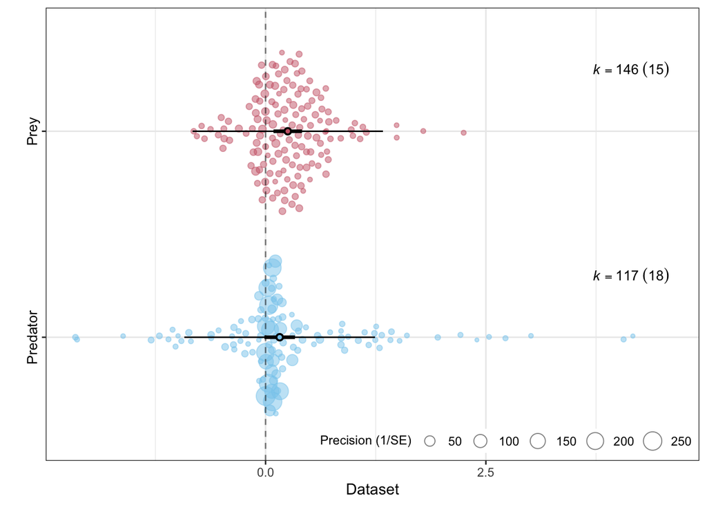

```r
orchard_plot(mr_dataset,
            mod = "Dataset",
            group = "Study_ID",
            xlab = "Dataset")
```

**Background area (mm²)**

```r
mr_background <- rma.mv(yi = lnRR,
                        V = VCV,
                        mods = ~ Log_background,
                        random = list(~1 | Study_ID,
                                      ~1 | Obs_ID),
                        test = "t",
                        method = "REML",
                        sparse = TRUE,
                        data = dat)

summary(mr_background)
```

```
Multivariate Meta-Analysis Model (k = 263; method: REML)

   logLik   Deviance        AIC        BIC       AICc
-247.0585   494.1170   502.1170   516.3751   502.2732

Variance Components:

            estim    sqrt  nlvls  fixed    factor
sigma^2.1  0.0556  0.2358     32     no  Study_ID
sigma^2.2  0.2421  0.4920    263     no    Obs_ID

Test for Residual Heterogeneity:
QE(df = 261) = 6234.1356, p-val < .0001

Test of Moderators (coefficient 2):
F(df1 = 1, df2 = 261) = 0.2144, p-val = 0.6437

Model Results:

                estimate      se     tval   df    pval    ci.lb   ci.ub
intrcpt           0.4058  0.4286   0.9468  261  0.3446  -0.4382  1.2498
Log_background   -0.0282  0.0609  -0.4631  261  0.6437  -0.1480  0.0917

---
Signif. codes:  0 '***' 0.001 '**' 0.01 '*' 0.05 '.' 0.1 ' ' 1
```

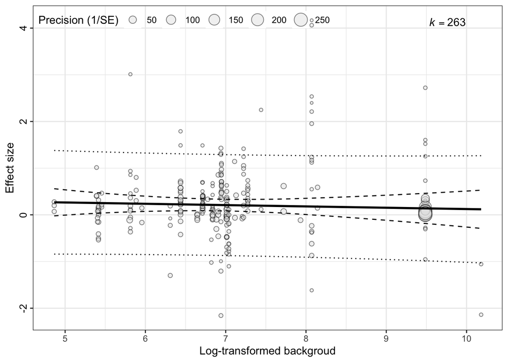

```r
bubble_plot(mr_background,
            mod = "Log_background",
            group = "Study_ID",
            xlab = "Log-transformed backgroud")
```

**R version 4.3.1 (2023-06-16)**

**Platform:** x86_64-apple-darwin20 (64-bit)

**locale:** en_US.UTF-8||en_US.UTF-8||en_US.UTF-8||C||en_US.UTF-8||en_US.UTF-8

**attached base packages:** *parallel*, *stats*, *graphics*, *grDevices*, *utils*, *datasets*, *methods* and *base*

**other attached packages:** *viridis(v.0.6.4)*, *viridisLite(v.0.4.2)*, *orchaRd(v.2.0)*, *miWQS(v.0.4.4)*, *metafor(v.4.2-0)*, *numDeriv(v.2016.8-1.1)*, *metadat(v.1.2-0)*, *Matrix(v.1.6-1)*, *lubridate(v.1.9.2)*, *forcats(v.1.0.0)*, *stringr(v.1.5.0)*, *dplyr(v.1.1.2)*, *purrr(v.1.0.2)*, *readr(v.2.1.4)*, *tidyr(v.1.3.0)*, *tibble(v.3.2.1)*, *ggplot2(v.3.4.3)*, *tidyverse(v.2.0.0)*, *here(v.1.0.1)*, *DT(v.0.28)* and *ape(v.5.7-1)*

**loaded via a namespace (and not attached):** *gridExtra(v.2.3)*, *glm2(v.1.2.1)*, *sandwich(v.3.0-2)*, *rlang(v.1.1.1)*, *magrittr(v.2.0.3)*, *compiler(v.4.3.1)*, *mgcv(v.1.8-42)*, *vctrs(v.0.6.3)*, *quantreg(v.5.97)*, *pkgconfig(v.2.0.3)*, *fastmap(v.1.1.1)*, *backports(v.1.4.1)*, *mcmc(v.0.9-7)*, *ellipsis(v.0.3.2)*, *labeling(v.0.4.2)*, *pander(v.0.6.5)*, *utf8(v.1.2.3)*, *rmarkdown(v.2.24)*, *tzdb(v.0.4.0)*, *ggbeeswarm(v.0.7.2)*, *MatrixModels(v.0.5-2)*, *xfun(v.0.40)*, *cachem(v.1.0.8)*, *jsonlite(v.1.8.7)*, *gmm(v.1.8)*, *cluster(v.2.1.4)*, *R6(v.2.5.1)*, *bslib(v.0.5.1)*, *stringi(v.1.7.12)*, *Rsolnp(v.1.16)*, *rlist(v.0.4.6.2)*, *rpart(v.4.1.19)*, *jquerylib(v.0.1.4)*, *estimability(v.1.4.1)*, *Rcpp(v.1.0.11)*, *knitr(v.1.43)*, *zoo(v.1.8-12)*, *tmvmixnorm(v.1.1.1)*, *base64enc(v.0.1-3)*, *pacman(v.0.5.1)*, *splines(v.4.3.1)*, *nnet(v.7.3-19)*, *timechange(v.0.2.0)*, *tidyselect(v.1.2.0)*, *rstudioapi(v.0.15.0)*, *yaml(v.2.3.7)*, *lattice(v.0.21-8)*, *withr(v.2.5.0)*, *coda(v.0.19-4)*, *evaluate(v.0.21)*, *tmvtnorm(v.1.5)*, *foreign(v.0.8-84)*, *survival(v.3.5-5)*, *pillar(v.1.9.0)*, *checkmate(v.2.2.0)*, *stats4(v.4.3.1)*, *generics(v.0.1.3)*, *rprojroot(v.2.0.3)*, *invgamma(v.1.1)*, *mathjaxr(v.1.6-0)*, *truncnorm(v.1.0-9)*, *hms(v.1.1.3)*, *munsell(v.0.5.0)*, *scales(v.1.2.1)*, *xtable(v.1.8-4)*, *glue(v.1.6.2)*, *emmeans(v.1.8.8)*, *Hmisc(v.5.1-0)*, *tools(v.4.3.1)*, *data.table(v.1.14.8)*, *SparseM(v.1.81)*, *matrixNormal(v.0.1.1)*, *mvtnorm(v.1.2-3)*, *grid(v.4.3.1)*, *MCMCpack(v.1.6-3)*, *crosstalk(v.1.2.0)*, *colorspace(v.2.1-0)*, *nlme(v.3.1-162)*, *beeswarm(v.0.4.0)*, *condMVNorm(v.2020.1)*, *vipor(v.0.4.5)*, *htmlTable(v.2.4.1)*, *latex2exp(v.0.9.6)*, *Formula(v.1.2-5)*, *cli(v.3.6.1)*, *fansi(v.1.0.4)*, *gtable(v.0.3.4)*, *sass(v.0.4.7)*, *digest(v.0.6.33)*, *farver(v.2.1.1)*, *htmlwidgets(v.1.6.2)*, *htmltools(v.0.5.6)*, *lifecycle(v.1.0.3)* and *MASS(v.7.3-60)*